# Machine Learning: AllLife Bank Personal Loan Campaign

#### Personal Loan vs Securities_Account

```
Securities_Account     0    1   All
Personal_Loan
All                 4478  522  5000
0                   4058  462  4520
1                    420   60   480
------------------------------------------------------------------------------------------------------------------------
```

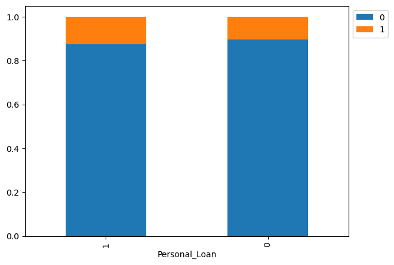

```python
stacked_barplot(loan_data,"Personal_Loan", "Securities_Account")
```

#### Observation between Personal loans and securitues Accounts.

- Based on the dataset you provided for the relationship between "Securities_Account" and the acceptance of personal loans, here are some insights:
- Customers with Securities Account Distribution: Out of the total 5000 customers:
  - 4478 customers have no securities account (0)
  - 522 customers have a securities account (1) Personal Loan Acceptance by Securities Account:
- Customers didn't accept the personal loan offered by bank:
- 4058 customers do not have a securities account (0)
- 462 customers have a securities account (1)
- Among customers who accepted the personal loan:
- 420 customers do not have a securities account (0)
- 60 customers have a securities account (1)

#### Personal Loan vs CD_Account

```
CD_Account        0    1   All
Personal_Loan
All            4698  302  5000
0              4358  162  4520
1               340  140   480
------------------------------------------------------------------------------------------------------------------------
```

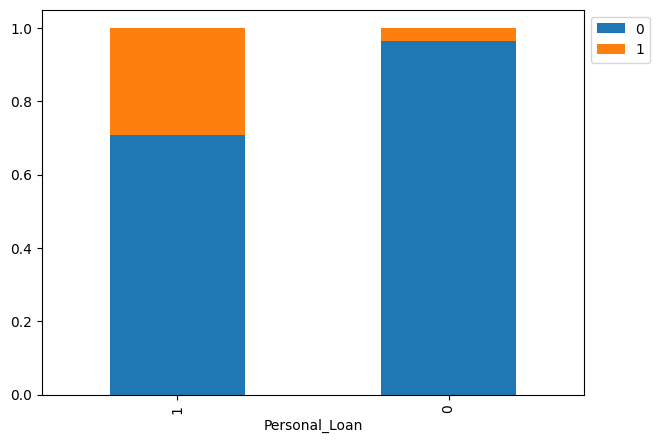

```python
stacked_barplot(loan_data,"Personal_Loan", "CD_Account")
```

#### Personal Loan vs Online

```
Online            0     1   All
Personal_Loan
All            2016  2984  5000
0              1827  2693  4520
1               189   291   480
------------------------------------------------------------------------------------------------------------------------
```

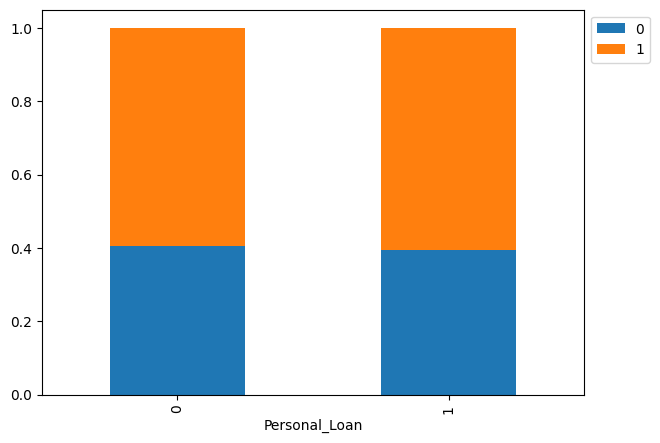

```python
stacked_barplot(loan_data,"Personal_Loan", "Online")
```

#### Observation on Personal Loans and Online Banking

- Overall Online Banking Usage: Total 5000 customers:
  - 2016 customers do not use online banking (0)
  - 2984 customers use online banking (1) Personal Loan Acceptance by Online Banking Usage:
- Among customers who did not accept the personal loan:
  - 1827 customers do not use online banking (0)
  - 2693 customers use online banking (1)
- Among customers who accepted the personal loan:
  - 189 customers do not use online banking (0)
  - 291 customers use online banking (1)
- Based on these insights, we can observe that the proportion of customers accepting personal loans is slightly higher among those who use online banking compared to those who do not. This information can be useful for targeted marketing campaigns, personalized loan offers, or understanding the relationship between online banking usage and the acceptance of personal loans.

#### Personal Loan vs CreditCard

```
CreditCard        0     1   All
Personal_Loan
All            3530  1470  5000
0              3193  1327  4520
1               337   143   480
------------------------------------------------------------------------------------------------------------------------
```

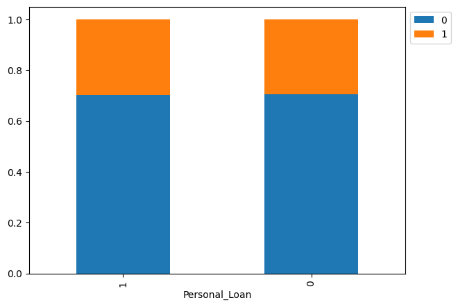

```python
stacked_barplot(loan_data,"Personal_Loan", "CreditCard")
```

#### Personal Loan vs Zipcode

```
ZIPCode         90   91   92   93    94   95  96   All
Personal_Loan
All            703  565  988  417  1472  815  40  5000
0              636  510  894  374  1334  735  37  4520
1               67   55   94   43   138   80   3   480
------------------------------------------------------------------------------------------------------------------------
```

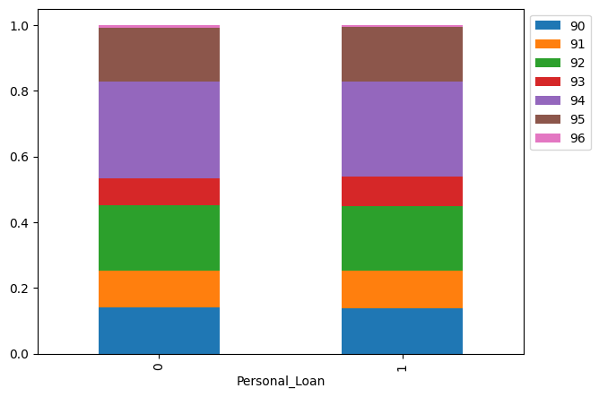

```python
stacked_barplot(loan_data,"Personal_Loan", "ZIPCode")
```

#### Observation on personal Loan and ZIPcodes

```
Securities_Account     0    1   All
Personal_Loan
All                 4478  522  5000
0                   4058  462  4520
1                    420   60   480
------------------------------------------------------------------------------------------------------------------------
```

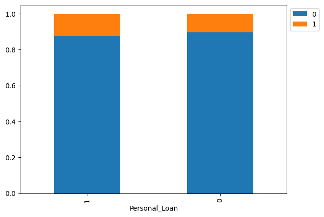

```python
stacked_barplot(loan_data,"Personal_Loan", "Securities_Account")
```

#### Relation between Customer's Age and Obtaining Personal Loan relation to age

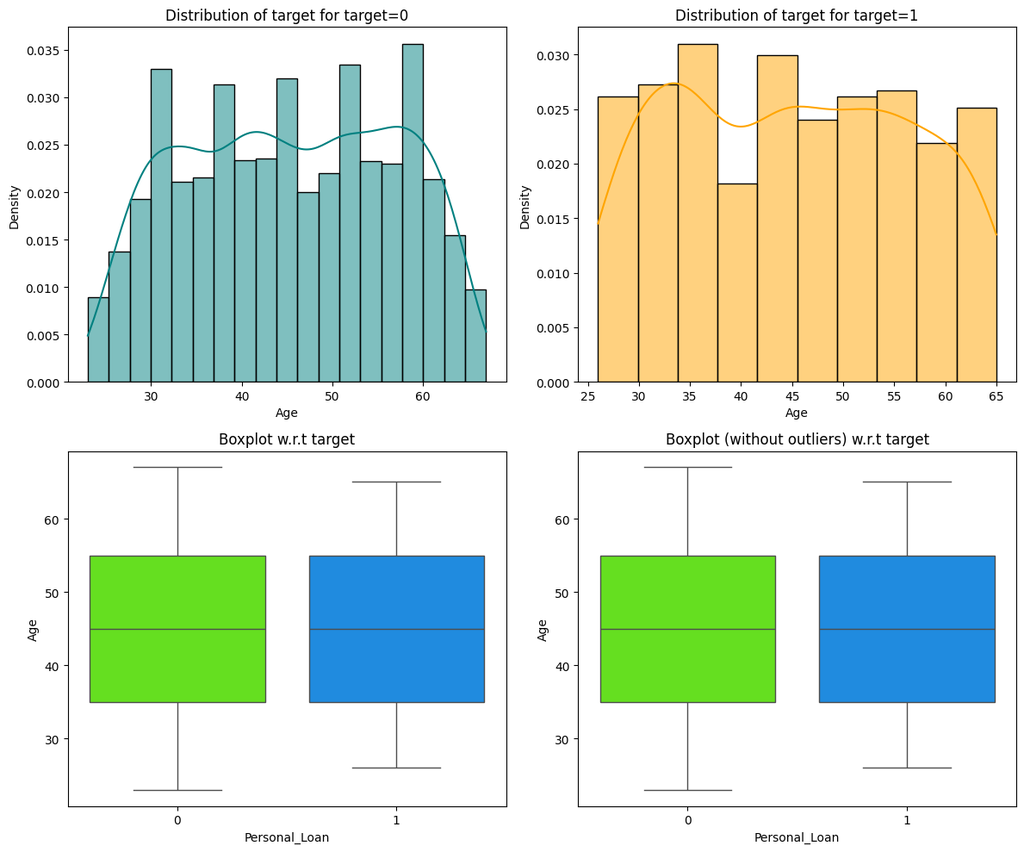

```python
distribution_plot_wrt_target(loan_data, "Age", "Personal_Loan")
```

#### Personal Loan vs CCAvg

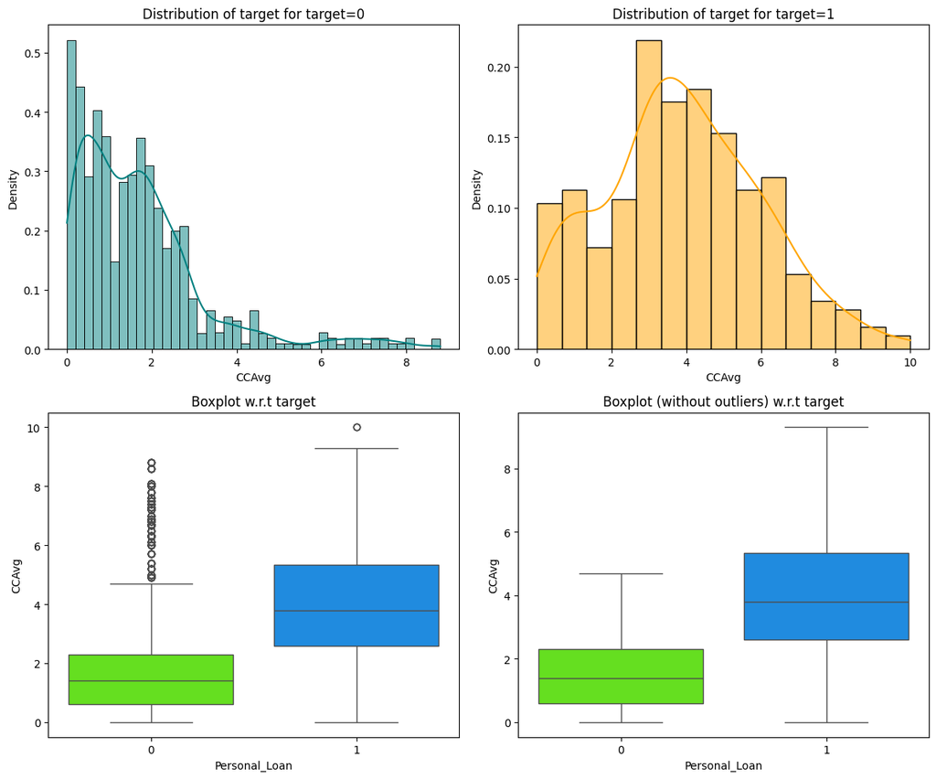

```python
distribution_plot_wrt_target(loan_data, "CCAvg", "Personal_Loan")
```

#### Personal Loan vs Experience

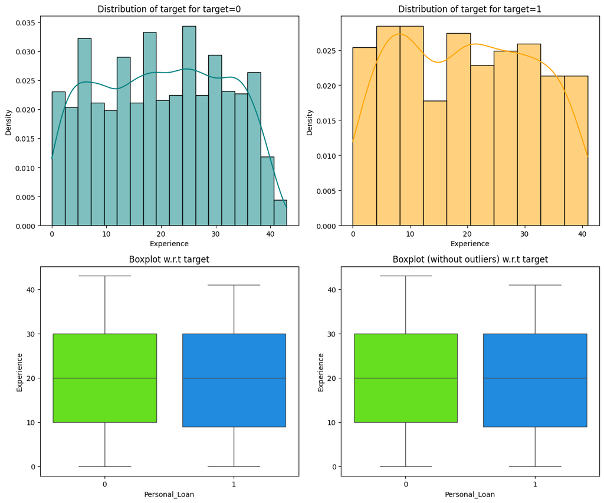

```python
distribution_plot_wrt_target(loan_data, "Experience", "Personal_Loan")
```

#### Personal Loan vs Income

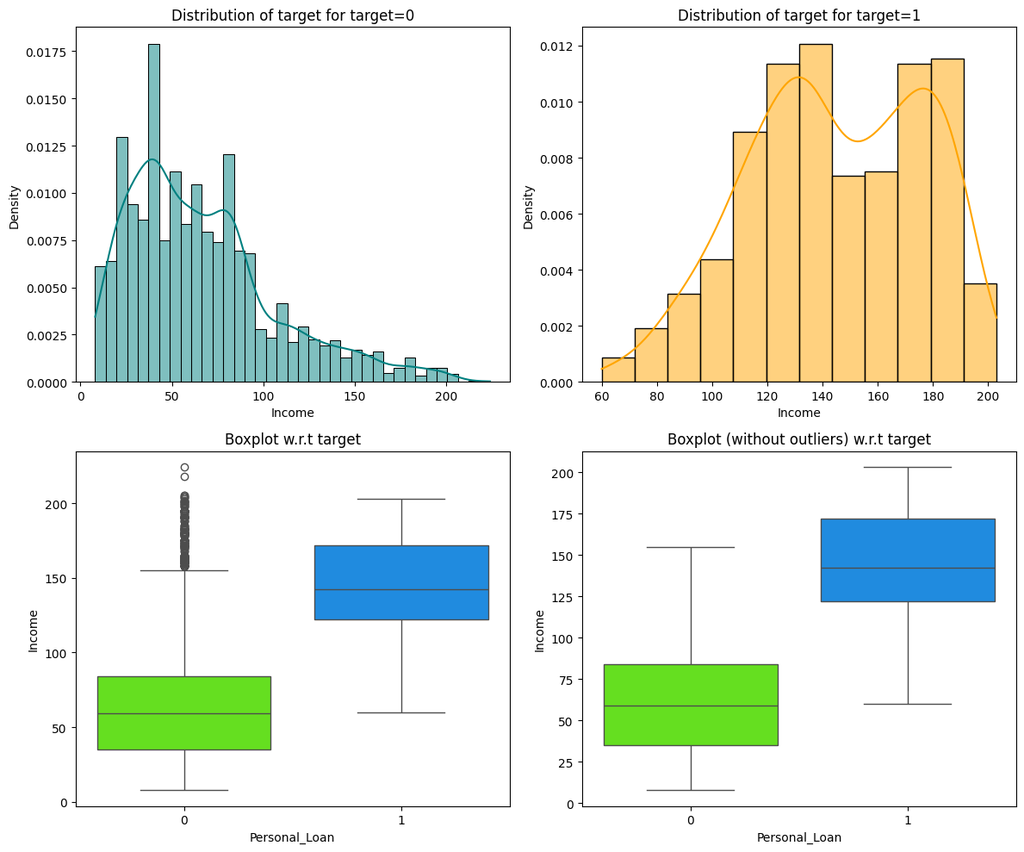

```python
distribution_plot_wrt_target(loan_data, "Income", "Personal_Loan")
```

#### Personal Loan vs Zipcode

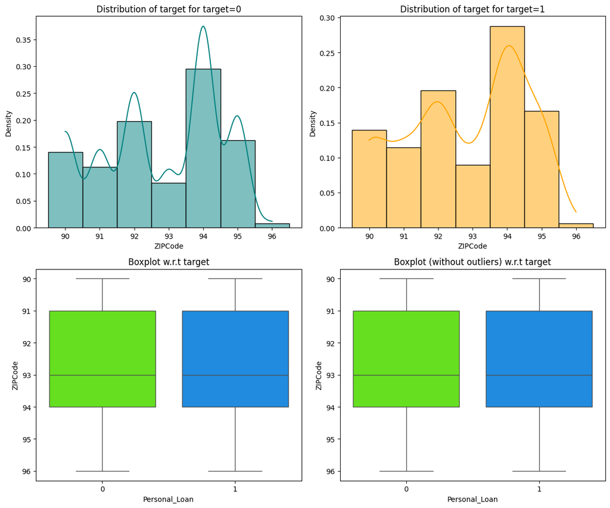

```python
distribution_plot_wrt_target(loan_data, "ZIPCode", "Personal_Loan")
```

### Outlier detection and treatment

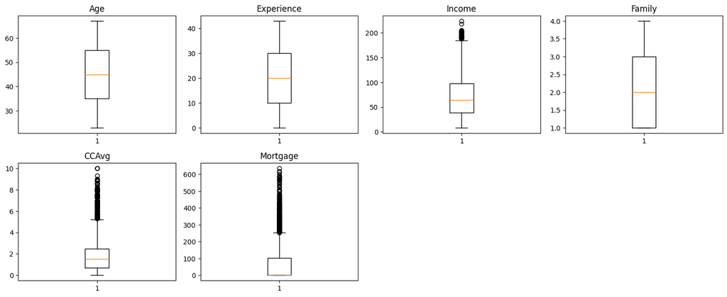

```python
# outlier detection using boxplot
numeric_columns = loan_data.select_dtypes(include=np.number).columns.tolist()

plt.figure(figsize=(15, 12))

for i, variable in enumerate(numeric_columns):
    plt.subplot(4, 4, i + 1)
    plt.boxplot(loan_data[variable], whis=1.5)
    plt.tight_layout()
    plt.title(variable)

plt.show()
```

#### Inter Quartile Range

```python
loan_data.info()
```

```
<class 'pandas.core.frame.DataFrame'>
RangeIndex: 5000 entries, 0 to 4999
Data columns (total 13 columns):
 #   Column              Non-Null Count  Dtype
---  ------              --------------  -----
 0   Age                 5000 non-null   int64
 1   Experience          5000 non-null   int64
 2   Income              5000 non-null   int64
 3   ZIPCode             5000 non-null   category
 4   Family              5000 non-null   int64
 5   CCAvg               5000 non-null   float64
 6   Education           5000 non-null   category
 7   Mortgage            5000 non-null   int64
 8   Personal_Loan       5000 non-null   category
 9   Securities_Account  5000 non-null   category
 10  CD_Account          5000 non-null   category
 11  Online              5000 non-null   category
 12  CreditCard          5000 non-null   category
dtypes: category(7), float64(1), int64(5)
memory usage: 269.8 KB
```

```python
def find_iqr(x):
    return np.subtract(*np.percentile(x, [75, 25]))
```

```python
loan_data_numeric = loan_data.select_dtypes(include=["float64", "int64"])
loan_data_numeric
Q1 = loan_data_numeric.quantile(0.25)
print(Q1)
Q3= loan_data_numeric.quantile(0.75)
Q3
```

```
Age           35.0
Experience    10.0
Income        39.0
Family         1.0
CCAvg          0.7
Mortgage       0.0
Name: 0.25, dtype: float64
```

```
Age            55.0
Experience     30.0
Income         98.0
Family          3.0
CCAvg           2.5
Mortgage      101.0
Name: 0.75, dtype: float64
```

```python
IQR = Q3 - Q1
lower = Q1 - 1.5 * IQR
upper = Q3 + 1.5 * IQR
print(lower)
print(upper)
```

```
Age             5.0
Experience    -20.0
Income        -49.5
Family         -2.0
CCAvg          -2.0
Mortgage     -151.5
dtype: float64
Age            85.0
Experience     60.0
Income        186.5
Family          6.0
CCAvg           5.2
Mortgage      252.5
dtype: float64
```

#### Treating the outlers after the IQR calculation

```python
((loan_data.select_dtypes(include=["float64", "int64"]) < lower)
    |(loan_data.select_dtypes(include=["float64", "int64"]) > upper)
).sum() / len(loan_data) * 100
```

[output not shown]

## Model Building

#### Data Preperation for Modelling

```python
# Prepare the data for modeling, For the X variable, remove the "Personal_Loan" and "Experience" columns and store the remaining
X = loan_data.drop(["Personal_Loan", "Experience"], axis=1)
# Prepare the data for modeling, For the Y variable, remove the "Personal_Loan" column
Y = loan_data["Personal_Loan"]
```

#### Prepare the category variables and prepare the data for modeling

```python
# drop the zipcode and Education column and replace with dummies
X = pd.get_dummies(X, columns=["ZIPCode", "Education"])
# Splitting data in train and test sets
X_train, X_test, y_train, y_test = train_test_split(X, Y, test_size=0.30, random_state=1, stratify=Y)
```

```python
print("Shape of Training set : ", X_train.shape)
print("Shape of test set : ", X_test.shape)
print("Percentage of classes in training set:")
print(y_train.value_counts(normalize=True))
print("Percentage of classes in test set:")
print(y_test.value_counts(normalize=True))
```

```
Shape of Training set :  (3500, 19)
Shape of test set :  (1500, 19)
Percentage of classes in training set:
Personal_Loan
0    0.904
1    0.096
Name: proportion, dtype: float64
Percentage of classes in test set:
Personal_Loan
0    0.904
1    0.096
Name: proportion, dtype: float64
```

### Model Evaluation Criterion

**Model can make wrong predictions as:**

1. Predicting a customer will take the personal loan but in reality the customer will not take the personal loan - Loss of resources
2. Predicting a customer will not take the personal loan but in reality the customer was going to take the personal loan - Loss of opportunity

**Which case is more important?**

- Losing a potential customer by predicting that the customer will not be taking the personal loan but in reality the customer was going to take the personal loan.

**How to reduce this loss i.e need to reduce False Negatives?**

- Bank would want `Recall` to be maximized, greater the Recall higher the chances of minimizing false negatives. Hence, the focus should be on increasing Recall or minimizing the false negatives.

### Model Building

```python
# function to compute different metrics to check performance of a classification model built using sklearn algorithms
def model_perf_classfn_sklearn(model, predictors, target):
    """
    Function to compute different metrics to check classification model performance

    model: classifier
    predictors: independent variables
    target: dependent variable
    """

    # predicting using the independent variables
    pred = model.predict(predictors)

    acc = accuracy_score(target, pred)  # compute the Accuracy
    recall = recall_score(target, pred)  # compute the Recall
    precision = precision_score(target, pred)  # compute the Precision
    f1 = f1_score(target, pred)  # to compute F1-score

    # creating a dataframe of metrics
    dataframe_performance = pd.DataFrame(
        {"Accuracy": acc, "Recall": recall, "Precision": precision, "F1": f1,},
        index=[0],
    )

    return dataframe_performance
```

```python
def confusion_matrix_sklearn(model, predictors, target):
    """
    To plot the confusion_matrix with percentages

    model: classifier
    predictors: independent variables
    target: dependent variable
    """
    y_pred = model.predict(predictors)
    cm = confusion_matrix(target, y_pred)
    labels = np.asarray(
        [
            ["{0:0.0f}".format(item) + "\n{0:.2%}".format(item / cm.flatten().sum())]
            for item in cm.flatten()
        ]
    ).reshape(2, 2)

    plt.figure(figsize=(6, 4))
    sns.heatmap(cm, annot=labels, fmt="")
    plt.ylabel("True label")
    plt.xlabel("Predicted label")
```

```python
# Initializing the decision tree classifier with criterion with gini type
model = DecisionTreeClassifier(criterion="gini", random_state=1)
model.fit(X_train, y_train)  # Fit the decision tree with training data set with both x_train and y_train
```

```
DecisionTreeClassifier(random_state=1)
```

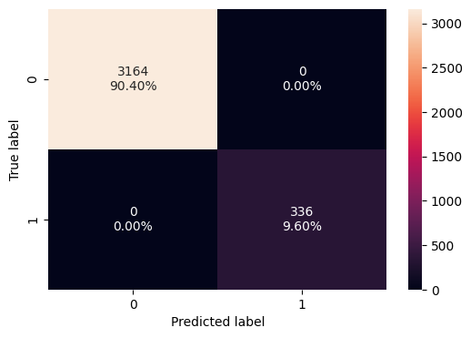

```python
# generate the confusion matrix model
confusion_matrix_sklearn(model, X_train, y_train)
```

[output not shown]

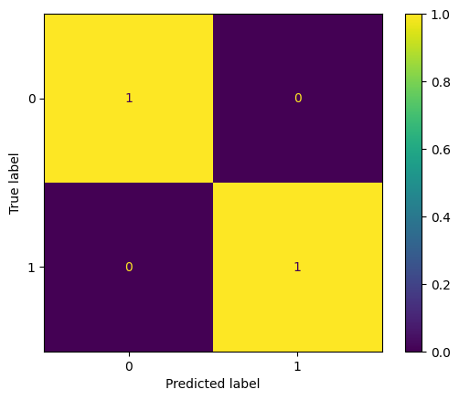

```python
ConfusionMatrixDisplay.from_estimator(model, X_train, y_train, normalize = "true")
```

#### Observation on Training data confusion matrix

- The confusion matrix shows the percentage of correctly classified samples.
- It has zero flase positives and zero false negatives.
- The trained model is classified to acccurate for training data.

```python
decision_tree_perf_train = model_perf_classfn_sklearn(model, X_train, y_train)
decision_tree_perf_train
```

|  | Accuracy | Recall | Precision | F1 |
| --- | --- | --- | --- | --- |
| 0 | 1.0 | 1.0 | 1.0 | 1.0 |

```python
decision_tree_perf_test = model_perf_classfn_sklearn(model, X_test, y_test)
decision_tree_perf_test
```

|  | Accuracy | Recall | Precision | F1 |
| --- | --- | --- | --- | --- |
| 0 | 0.978 | 0.854167 | 0.911111 | 0.88172 |

#### Logistic regression

[output not shown]

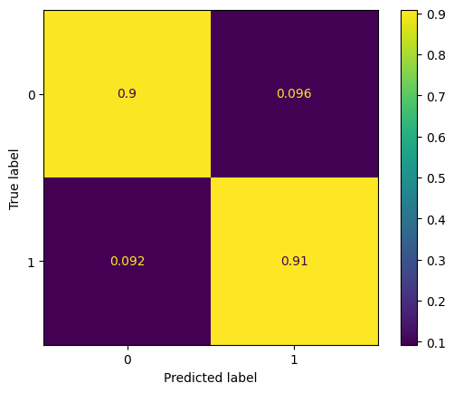

```python
model_lr = LogisticRegression(
    solver = "newton-cg",
    max_iter = 200,
    class_weight = "balanced",
    random_state = 42
).fit(X_train, y_train)

ConfusionMatrixDisplay.from_estimator(model_lr, X_train, y_train, normalize = "true")

lr_train_metrics =  model_perf_classfn_sklearn(model, X_train, y_train)
(
    model_lr, X_train, y_train
)

lr_train_metrics
```

#### Logisti Regression for Testing data

|  | Accuracy | Recall | Precision | F1 |
| --- | --- | --- | --- | --- |
| 0 | 0.906667 | 0.854167 | 0.508264 | 0.637306 |

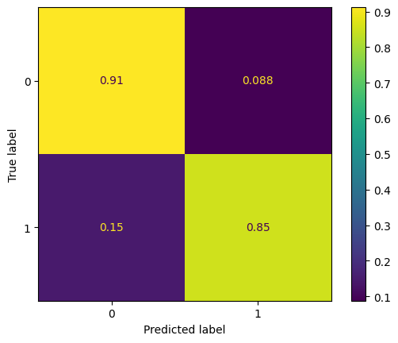

```python
ConfusionMatrixDisplay.from_estimator(model_lr, X_test, y_test, normalize = "true")

lr_test_metrics = model_perf_classfn_sklearn(
    model_lr, X_test, y_test
)

lr_test_metrics
```